# Munsell Projection of Saliency-Weighted Colors

Projecting per-concept saliency-weighted color distributions onto WCS Munsell chips

Author

Thomas Brochhagen

Published

March 4, 2026

## Overview

This report documents step 3 of the pipeline: projecting each concept’s saliency-weighted color distribution onto the 330 WCS Munsell chips so that it can be compared with cross-linguistic focal-color data.

| Step | Script | Description |
| --- | --- | --- |
| 1–2 | `04-fetch-images.py` | Download bbox-cropped images per concept |
| **3** | **`06-munsell-projection.py`** | **Saliency-weighted Munsell distribution per concept** |
| 4 | `07-comparison-plot.py` | Aggregate distributions vs WCS focal colors (see below) |

Steps 3 and 4 are independent — `07-comparison-plot.py` reads only pre-computed `.npy` files and the WCS data; it can be re-run freely to change plot aesthetics, weighting, or filtering without touching step 3. Step 3 requires GBVS (MATLAB) and takes ~2 min/concept for at most 20 images per concept.

The central idea is:

> For each image of a concept, run GBVS to obtain a per-image saliency map. Weight each pixel’s color by its saliency value (how visually prominent that pixel is). Average those saliency-weighted color distributions across all images for the concept. Find the nearest Munsell chip for each pixel in CIELab space, accumulating saliency weights per chip.

The output is a probability distribution over the 330 WCS Munsell chips for every concept. This can be compared with WCS speakers’ focal-color choices to test whether a concept’s typical color aligns with the focal color of the linguistic term used to name it across languages.

Note that, for now, each image of a concept contributes the same total weight to the concept distribution (so a very clean *banana* image adds the same as a very poor *banana* image); and the each concept’s distribution adds the same to the contour plot (so *banana* serving as a source for a single color terms makes it contribute the same as *rose* contributing to 20+ color terms). **[CIRCLE BACK TO]**.

## Decisions

### P1 — Canonical image size: 256 × 256 px

**Decision**: all images are resized to 256 × 256 before GBVS computation.

**Rationale**: a common spatial resolution is required to process images uniformly. 256 × 256 retains sufficient colour and spatial detail while remaining fast; GBVS internally downsamples to `salmapmaxsize = 32` px regardless of input size, so larger inputs yield negligible additional resolution in the saliency map.

**Consequence**: removes natural variation in image scale. Close-up crops and wide-field images are treated identically once resized.

### P2 — Aspect ratio: squish to square

**Decision**: images are resized to 256 × 256 without padding, squishing the aspect ratio.

**Rationale**: the goal is colour-based saliency, not shape recognition. Mild spatial distortion (hopefully) does not affect which colour regions receive high saliency (much). Padding with a neutral colour would introduce an artificial border whose saliency contribution is unclear.

**Which means that**: strongly elongated images (e.g., a horizontal landscape) are vertically compressed; the saliency distribution may shift slightly toward the centre.

**Possible solution**: I saw that other papers (e.g., Kay & Regier 2003 or Regier et al. 2005) restrict at least some of their analyses to the 320 chromatic WCS chips: lightness rows B–I, hue columns 1–40. Excluded: row A (pure white, A0), row J (pure black, J0), and hue column 0 (near-neutral chips in every row). I’m doing the same below. So maybe the colors corresponding to these excluded rows could be used as padding to not squish the aspect ration?

But this would introduce a large achromatic border around every image, which would likely receive high saliency and thus distort the distribution. The squishing approach is simpler. I’m inclined to believe it is less likely to introduce artefacts, even if it does distort the spatial layout slightly. But let’s discuss.

### P3 — GBVS parameters

**Decision**: GBVS is run with `channels='DIO'` (DKL colour, intensity, orientation), `salmapmaxsize=32`, `blurfrac=0.02`.

**Rationale**: these are the standard parameters from Harel et al. (2006) — the original GBVS paper. `salmapmaxsize=32` is the default internal map resolution; `blurfrac=0.02` applies a small final Gaussian to smooth quantisation artefacts from the low-resolution internal map.

The DIO channel set responds to low-level visual contrast. It does not incorporate semantic content; salient regions are determined by colour, intensity, and edge contrast rather than by object identity. This is what we had discussed some months back but worth reiterating here.

### D1 — Per-image GBVS saliency as pixel weights

**Decision**: GBVS is run independently on each image; the resulting per-image saliency map is used to weight that image’s pixel colors.

So every image depicts the concept differently and may have different salient regions. A saliency map computed for *this* image reflects *this* image’s visual structure.

A consequence is achromatic overrepresentation: GBVS is a bottom-up model responding to low-level color, intensity, and orientation contrast. Backgrounds, shadows, and bright neutral regions can thus also be visually salient. Across images, these kinds of regions accumulate disproportionate saliency weight. This results in achromatic Munsell chips (hue column 0: white through black) receiving systematically higher weights than their role in characterizing the concept’s color would warrant. In inspection of five prototype concepts (banana, sky, grass, rose, snow), the top-weighted chip in every case was an achromatic one; the correct chromatic peak was consistently present but ranked lower. I’m not sure what to do about this. One option would be to apply a chromaticity filter to the saliency map before weighting the pixels… I think this can be done. Also, in practical terms, if we follow the literature (e.g., Kay & Regier 2003) and restrict the comparison to chromatic chips only, then the achromatic overrepresentation is not a problem that shows directly. But I need to think about whether it indirectly affects the chromatic distribution that we do show… **[CIRCLE BACK TO]**

### D2 — Normalise per-image saliency to a probability distribution

**Decision**: after [0, 1] normalization, each saliency map is divided by its pixel sum, yielding a probability distribution over pixels.

**Rationale**: the absolute saliency amplitude varies across images. Without normalisation, high-contrast images would dominate the concept distribution. Normalising to a probability ensures every image contributes exactly equally, regardless of how visually “busy” it is.

A consequence of this is that an image with nearly uniform saliency (e.g., a plain-color background) is up-weighted relative to what might be considered its information content. Such images have little spatial structure, so the resulting distribution is approximately a uniform sample of the image’s colors.

### D3 — Unweighted mean over images

I mentioned this above but currently the concept-level Munsell distribution is the unweighted average of per-image distributions.

This is simple and consistent with the per-image normalisation in D2 (each image already contributes with equal total weight) but it doesn’t take into consideration quality nor cross-linguistic frequency.

I imagine that images with more images in the corpus benefit from this averaging effect; concepts with few images can be noisier. Since funky images (unusual lighting, cropping artifacts, very different scene composition) contribute equally to the mean.

### D4 — Nearest-neighbour in CIELab (Euclidean) for chip assignment

**Decision**: each pixel is assigned to the Munsell chip whose (L*, a*, b*) coordinates are nearest under Euclidean distance.

**Rationale**: CIELab is designed to be approximately perceptually uniform, so Euclidean distance in Lab is a reasonable proxy for perceived color difference. I think this is the standard approach in the WCS literature but we should double-check this carefully ** [CIRCLE BACK TO]**.

Euclidean Lab distance is an approximation to CIEDE2000 (the most precise perceptual distance metric). Errors are largest near saturated hues; for the lightly-saturated chip space of WCS, the impact is probably small.

### D5 — D65 illuminant for sRGB → CIELab conversion

**Decision**: `skimage.color.rgb2lab` is called with its default D65 illuminant for the sRGB → CIELab conversion.

**Rationale**: D65 (average daylight) is the standard reference illuminant for sRGB and for the WCS Lab coordinates in `cnum-vhcm-lab-new.txt`. Using the same illuminant ensures consistency between pixel Lab values and chip Lab coordinates.

Obviously this is not the best choice for images taken under non-daylight illumination (incandescent, fluorescent, flash). If I understand it correclty, this could introduce a hue shift for affected images. But I haven’t spent enough time reading into the documentation/literature on the Munsell/CIELab conversion to really digest the consequences for the images we’re dealing with.

Now onto some actual plots and results

## Coverage

```r
library(dplyr)
library(ggplot2)
library(readr)

manifest_path <- "../data/saliency/munsell_manifest.csv"

if (file.exists(manifest_path)) {
  mf <- read_csv(manifest_path, show_col_types = FALSE)

  done    <- sum(mf$status == "ok",         na.rm = TRUE)
  skipped <- sum(grepl("skipped", mf$status), na.rm = TRUE)
  failed  <- nrow(mf) - done - skipped

  cat(sprintf("Concepts processed:  %d\n", nrow(mf)))
  cat(sprintf("  Computed:          %d\n", done))
  cat(sprintf("  Skipped (cached):  %d\n", skipped))
  cat(sprintf("  Failed:            %d\n", failed))
} else {
  cat("Munsell projection not yet run.  Execute scripts/06-munsell-projection.py first.\n")
}
```

```
Concepts processed:  95
  Computed:          76
  Skipped (cached):  19
  Failed:            0
```

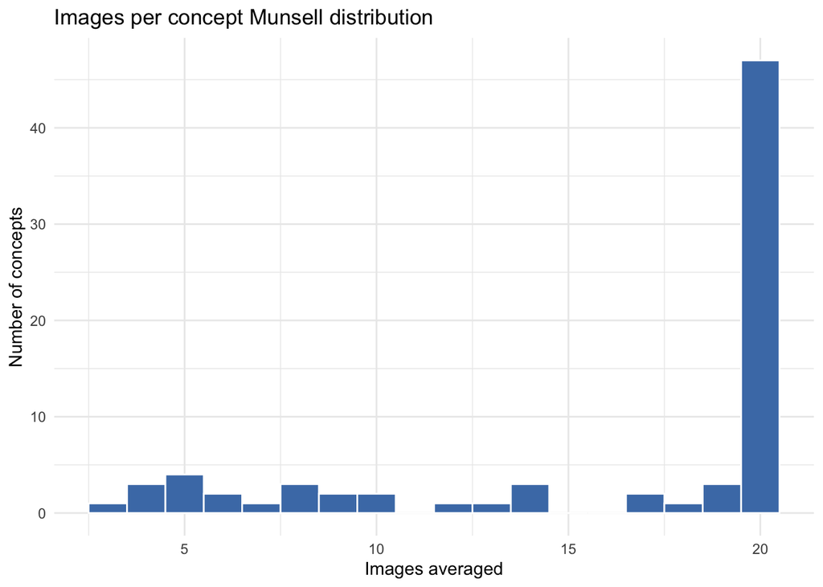

Distribution of images used per concept Munsell distribution

```r
if (file.exists(manifest_path)) {
  mf |>
    filter(status == "ok") |>
    ggplot(aes(x = n_images)) +
    geom_histogram(binwidth = 1, fill = "#4a7cb5", colour = "white") +
    labs(x = "Images averaged", y = "Number of concepts",
         title = "Images per concept Munsell distribution") +
    theme_minimal()
}
```

## Sanity check: known-color concepts

The distributions for banana (yellow), sky (blue), and grass (green) should peak in the expected Munsell regions:

- **Banana** → low hue (~4–8), mid lightness (rows C–D)
- **Sky** → high hue (~26–30), mid lightness (rows D–E)
- **Grass** → mid hue (~16–20), mid lightness (rows D–E)

```r
library(tidyr)

wcs_chips_path <- "../data/wcs/cnum-vhcm-lab-new.txt"

load_dist <- function(slug) {
  path <- file.path("../data/saliency", slug, "munsell_distribution.csv")
  if (!file.exists(path)) return(NULL)
  read_csv(path, show_col_types = FALSE) |> mutate(concept = slug)
}

check_concepts <- c("banana", "sky", "grass")
dists <- lapply(check_concepts, load_dist)
dists <- dists[!sapply(dists, is.null)]

if (length(dists) > 0) {
  all_dists <- bind_rows(dists)

  all_dists |>
    group_by(concept) |>
    arrange(desc(weight)) |>
    slice_head(n = 5) |>
    select(concept, V, H, MunH, MunV, weight) |>
    knitr::kable(caption = "Top-5 Munsell chips by saliency weight for three sanity-check concepts (V = lightness row A–J; H = hue column 0–40; MunH = Munsell hue name; MunV = Munsell lightness 0–10; weight = saliency probability)",
                 digits = 4)
} else {
  cat("No distributions found yet — run script 06 first.\n")
}
```

Top-5 Munsell chips by saliency weight for three sanity-check concepts (V = lightness row A–J; H = hue column 0–40; MunH = Munsell hue name; MunV = Munsell lightness 0–10; weight = saliency probability)

| concept | V | H | MunH | MunV | weight |
| --- | --- | --- | --- | --- | --- |
| banana | J | 0 | 10.00RP | 1.5 | 0.0840 |
| banana | E | 0 | 10.00RP | 6.0 | 0.0396 |
| banana | F | 0 | 10.00RP | 5.0 | 0.0396 |
| banana | G | 0 | 10.00RP | 4.0 | 0.0369 |
| banana | D | 9 | 2.50Y | 7.0 | 0.0300 |
| grass | J | 0 | 10.00RP | 1.5 | 0.0857 |
| grass | G | 14 | 5.00GY | 4.0 | 0.0831 |
| grass | F | 0 | 10.00RP | 5.0 | 0.0548 |
| grass | G | 13 | 2.50GY | 4.0 | 0.0486 |
| grass | G | 0 | 10.00RP | 4.0 | 0.0469 |
| sky | D | 0 | 10.00RP | 7.0 | 0.0813 |
| sky | E | 0 | 10.00RP | 6.0 | 0.0792 |
| sky | F | 0 | 10.00RP | 5.0 | 0.0719 |
| sky | J | 0 | 10.00RP | 1.5 | 0.0687 |
| sky | C | 0 | 10.00RP | 8.0 | 0.0559 |

For banana, the top 4 chips are all H=0 (achromatic) — that’s the D1 bias. The first chromatic entry is H=9, MunH=2.50Y (yellow), which is the correct answer. So the sanity check is working, just buried under achromatic noise. Sky is probably the worst-case concept for this achromatic bias. Grass is a little more encouraging. The top chip is still achromatic (J/H=0, near-black — likely dark soil or shadow), but the second-highest chip is already chromatic: G/H=14, MunH=5.00GY — that’s yellow-green, which is OK for grass. Chips 4 also lands in GY (yellow-green). **[TO BE DISCUSSED]**

## Heatmap examples

These show the issue of “achromatic overrepresentation” in a much clearer way (column 0 across concepts).

**Banana**

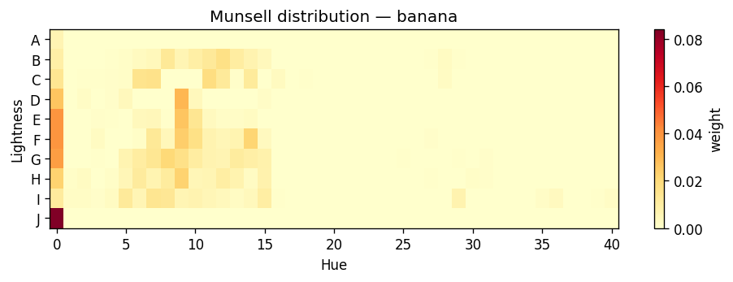

**Rose**

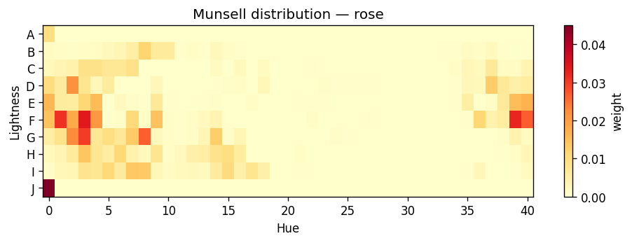

**Sky**

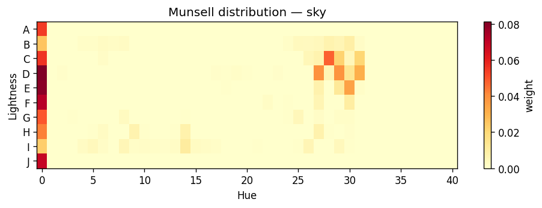

**Grass**

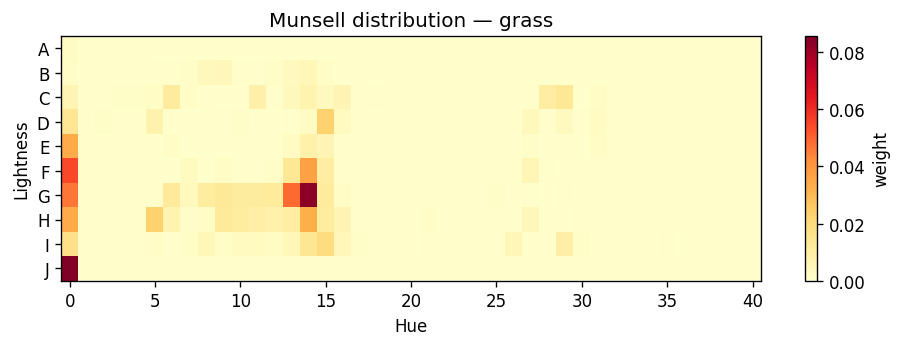

## Comparison with WCS cross-linguistic focal colors

Script `07-comparison-plot.py` produces six plots:

| File | Contents |
| --- | --- |
| `wcs_2d.png` / `wcs_3d.png` | WCS cross-linguistic focal color density only |
| `saliency_2d.png` / `saliency_3d.png` | Aggregate saliency-weighted Munsell distribution only |
| `comparison_2d.png` / `comparison_3d.png` | Both overlaid: WCS in black, saliency in blue |

Each 2D plot also has a `_colored` variant in which the Munsell chip squares are filled with their actual sRGB colour at low alpha, to ease interpretation.

**2D plots**: Gaussian-smoothed contour lines on a white (or chip-coloured) background. **3D plots**: surface height = smoothed density; axes are hue × lightness.

**Reading the plots**: the chromatic contour islands should ideally co-locate with the WCS focal color clusters (yellow, red, green, blue), providing a visual test of the hypothesis that a concept’s visual colour properties predict the focal color of the linguistic term used to name it.

**Concept weighting**: every concept contributes equally by default. To up-weight concepts that appear more frequently in cross-linguistic data, pass `--freq-file path/to/weights.csv` (columns `slug`, `weight`).

**WCS cross-linguistic focal color density**

**2D**

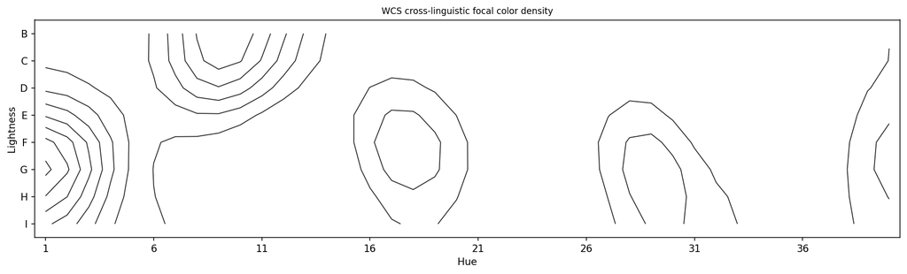

WCS focal color density — 2D contours, white background.

```r
knitr::include_graphics("wcs_2d.png")
```

**2D (chip colours)**

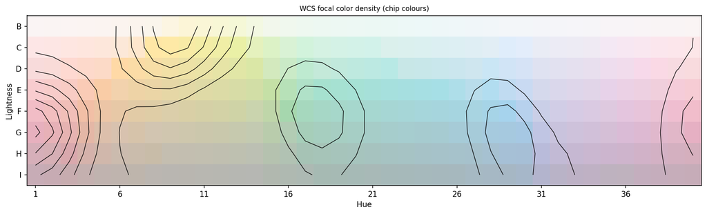

WCS focal color density — 2D contours, chip colours at low alpha.

```r
knitr::include_graphics("wcs_2d_colored.png")
```

**3D**

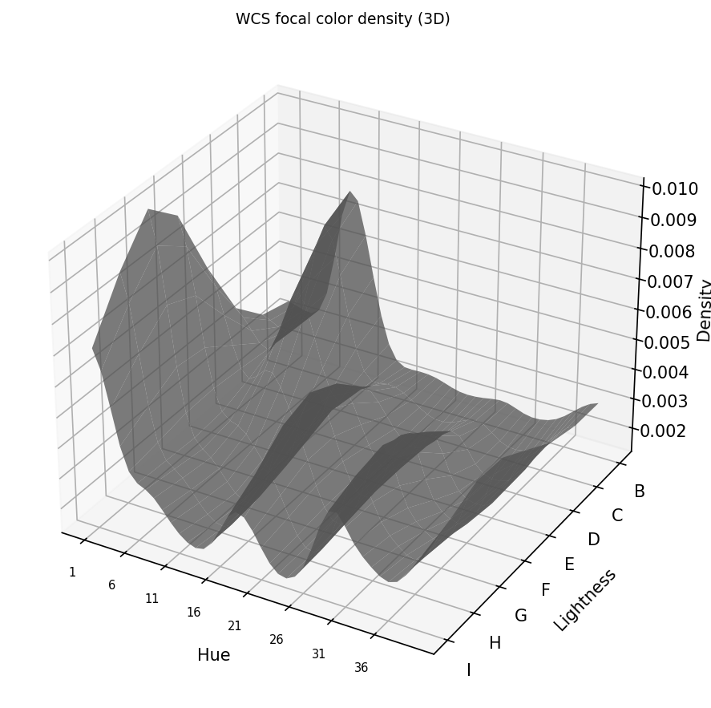

WCS focal color density — 3D surface, height = density.

```r
knitr::include_graphics("wcs_3d.png")
```

**Saliency-weighted Munsell distribution**

**2D**

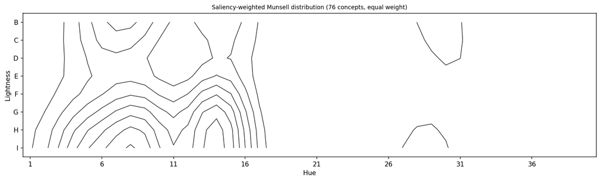

Aggregate saliency distribution — 2D contours, white background.

```r
knitr::include_graphics("saliency_2d.png")
```

**2D (chip colours)**

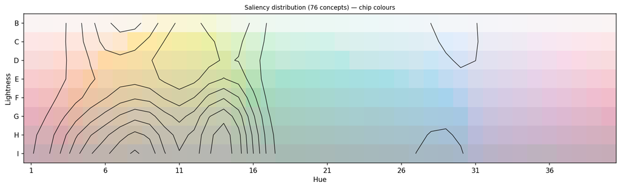

Aggregate saliency distribution — 2D contours, chip colours at low alpha.

```r
knitr::include_graphics("saliency_2d_colored.png")
```

**3D**

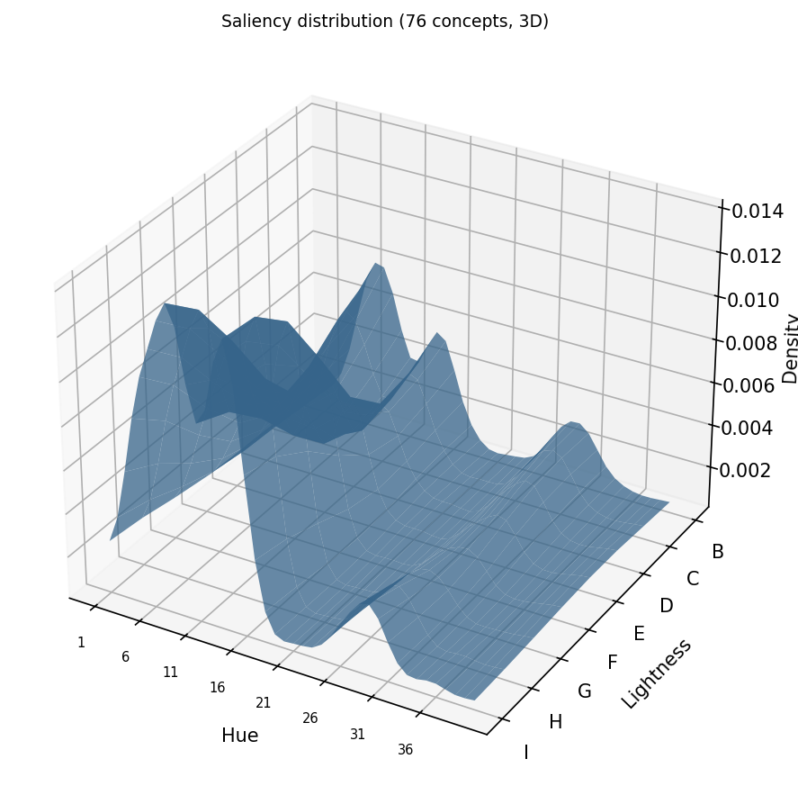

Aggregate saliency distribution — 3D surface, height = density.

```r
knitr::include_graphics("saliency_3d.png")
```

**Comparison: WCS (black) vs saliency (blue)**

**2D**

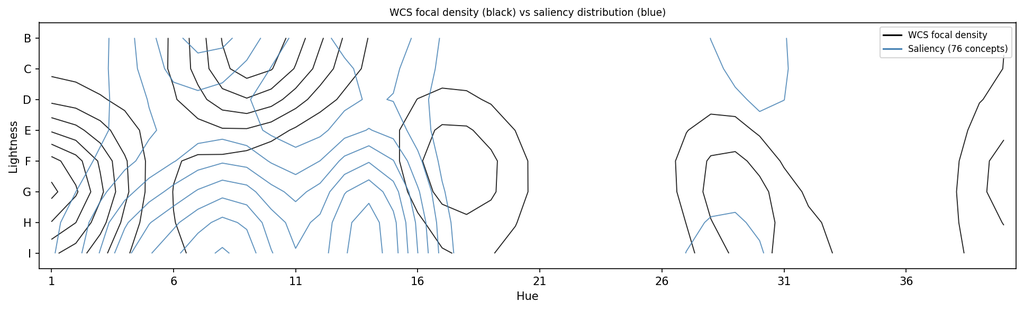

Comparison — 2D contours: WCS focal density (black), saliency distribution (blue).

```r
knitr::include_graphics("comparison_2d.png")
```

**2D (chip colours)**

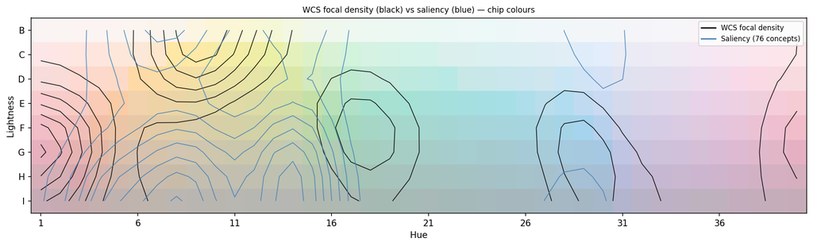

Comparison — 2D contours on chip-coloured background.

```r
knitr::include_graphics("comparison_2d_colored.png")
```

**3D**

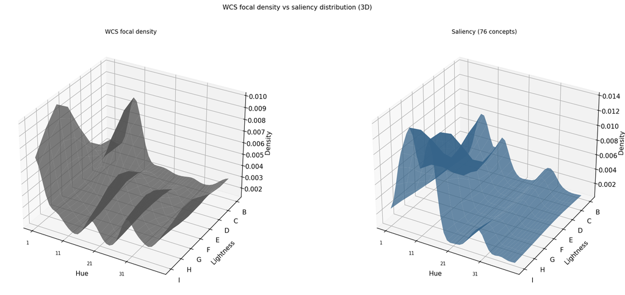

Comparison — side-by-side 3D surfaces: WCS (left) and saliency (right).

```r
knitr::include_graphics("comparison_3d.png")
```

## Comparison plot decisions (script 07)

### D6 — Restrict to 320 chromatic chips

As noted above, all plots are restricted to the 320 chromatic WCS chips: lightness rows B–I, hue columns 1–40. Excluded: row A (pure white, A0), row J (pure black, J0), and hue column 0 (near-neutral chips in every row).

**Potential issue for us**: a small number of concepts (snow, coal, fog, smoke) are genuinely white/black/grey and their distributions will be mis-represented in chromatic-only plots. Their achromatic weight is silently discarded; the remaining chromatic weight is re-normalised to sum to 1.

### D7 — Percentile-based contour levels

**Decision**: contour levels span the 60th–99.9th percentile of non-zero smoothed grid values, rather than a linear spacing from minimum to maximum.

**Rationale**: even after excluding rows A/J and column 0, the chromatic grid still has a small number of high-density cells and many near-zero cells. Linear min–max spacing packs most contour lines near zero (invisible) and leaves the interesting chromatic peaks sparsely contoured. Percentile-based spacing concentrates the contours on the informative upper part of the distribution.

However, the 60th-percentile floor clips low-density chips entirely; only chips above that threshold appear in the plot. This may hide weak but real colour preferences. **[CIRCLE BACK TO and see how it’s done in the literature]**

### D8 — Gaussian smoothing before contouring

I had the idea to use a Gaussian filter with σ = 1.5 grid cells to both the WCS and saliency grids before contouring or plotting the 3D surface.

The reason is that the chip grid is sparse (320 cells) and individual chips can have large counts due to sampling noise. My hope is that some soft smoothing reveals broad regional structure (the yellow/red/green/blue clusters) rather than single-chip spikes. σ = 1.5 corresponds to roughly 1–2 chip-widths, which may be appropriate for the resolution of the grid. But smoothing blurs the boundaries between adjacent hue regions. Narrowly localised focal color peaks (e.g., a single highly specific Munsell chip) will appear broader than they really are. **[CIRCLE BACK TO]**